# Final

Bingyan Liang

2023-05-13

## 1

```r
library(survival)
library(tidyverse)
# Read in data
invested <- read.table("invested2.txt", header = TRUE)
invested <- na.omit(invested)
invested <- invested[invested$time>0, ]

summary(invested)
```

```
##      patid             time              status          trtmnt
##  Min.   :100001   Min.   : 0.03279   Min.   :0.0000   Length:8405
##  1st Qu.:101068   1st Qu.: 6.09836   1st Qu.:0.0000   Class :character
##  Median :102363   Median : 9.14754   Median :0.0000   Mode  :character
##  Mean   :102467   Mean   :11.01043   Mean   :0.4849
##  3rd Qu.:103790   3rd Qu.:16.62295   3rd Qu.:1.0000
##  Max.   :105388   Max.   :34.19672   Max.   :2.0000
##     gender               age            race                dbmi
##  Length:8405        Min.   :20.00   Length:8405        Min.   :12.67
##  Class :character   1st Qu.:58.00   Class :character   1st Qu.:26.07
##  Mode  :character   Median :67.00   Mode  :character   Median :30.12
##                     Mean   :65.44                      Mean   :31.42
##                     3rd Qu.:74.00                      3rd Qu.:35.28
##                     Max.   :96.00                      Max.   :84.26
##    lveflt40           priormi            priorhf              diab
##  Length:8405        Length:8405        Length:8405        Length:8405
##  Class :character   Class :character   Class :character   Class :character
##  Mode  :character   Mode  :character   Mode  :character   Mode  :character
##
##
##
##     renal             ischstr              pad
##  Length:8405        Length:8405        Length:8405
##  Class :character   Class :character   Class :character
##  Mode  :character   Mode  :character   Mode  :character
##
##
##
```

## 1.1

Tabulate the event rates by treatment group (SD vs HD) and overall for (1) death (overall survival); (1a) death before hospitalization; (1b) death after hospitalization; (2) first hospitalization; (3) recurrent hospitalizations. Comment on the results.

[output not shown]

```r
index <- order(invested$patid, invested$time)
data <- invested[index,]
before_hosp <- data[ !duplicated(data$patid), ]
before <- before_hosp[ before_hosp$status==2, ]

event2 <- c(sum(before$status[before$trtmnt=="HD"]>0),
            sum(before$status[before$trtmnt=="SD"]>0),
            sum(before$status>0))

time2 <- c(sum(before_hosp$time[before_hosp$trtmnt=="HD"]),
           sum(before_hosp$time[before_hosp$trtmnt=="SD"]),
           sum(before_hosp$time))/12

rate2 <- round(event2/time2, 3)
rate2 <- rbind(title, rate2)
#Event Rate for death before hospitalization
rate2
```

```
##       [,1]   [,2]    [,3]
## title "HD"   "SD"    "Overall"
## rate2 "0.04" "0.037" "0.038"
```

```r
index <- order(invested$patid, invested$time)
data <- invested[index, ]
after_hosp <- data[!duplicated(data$patid), ]
after <- after_hosp[after_hosp$status==1, ]
deaths <- length(which(data$status==2))

event3 <- c(sum(after$status[after$trtmnt=="HD"]>0),
            sum(after$status[after$trtmnt=="SD"]>0),
            sum(after$status>0)) - deaths

time3 <- c(sum(after_hosp$time[after_hosp$trtmnt=="HD"]),
              sum(after_hosp$time[after_hosp$trtmnt=="SD"]),
              sum(after_hosp$time))/12

rate3 <- round(event3/time3, 3)
rate3 <- rbind(title, rate3)

# event Rate for death after hospitalization
rate3
```

```
##       [,1]    [,2]    [,3]
## title "HD"    "SD"    "Overall"
## rate3 "0.187" "0.169" "0.276"
```

```r
data.CE <- data[!duplicated(data$patid), ]
first <- data.CE[data.CE$status==1, ]

event4 <- c(sum(first$status[first$trtmnt=="HD"]>0),
            sum(first$status[first$trtmnt=="SD"]>0),
            sum(first$status>0))

time4 <- c(sum(data.CE$time[data.CE$trtmnt=="HD"]),
           sum(data.CE$time[data.CE$trtmnt=="SD"]),
           sum(data.CE$time))/12

rate4 <- round(event4/time4, 3)
rate4 <- rbind(title, rate4)

# event Rate for first hospitalization:
rate4
```

```
##       [,1]    [,2]    [,3]
## title "HD"    "SD"    "Overall"
## rate4 "0.385" "0.364" "0.374"
```

```r
event <- c(sum(invested$status[invested$trtmnt=="HD"]),
           sum(invested$status[invested$trtmnt=="SD"]),
           sum(invested$status>0))

index <- order(data$patid,data$time,decreasing = TRUE)
data <- invested[index,]

last <- data[!duplicated(data$patid),]

time <- c(sum(last$time[last$trt=="HD"]),
sum(last$time[last$trt=="SD"]),
sum(last$time))/12

rate <- round(event/time,3)
rate <- rbind(title, rate)
# event Rate for recurrent hospitalization:
rate
```

```
##       [,1]    [,2]    [,3]
## title "HD"    "SD"    "Overall"
## rate  "0.729" "0.701" "0.637"
```

Overall, the event rates for death and hospitalization are quite similar between the HD and SD groups. However, the event rate for recurrent hospitalization is higher in the HD group compared to the SD group. This suggests that patients in the HD group may have a higher risk of experiencing multiple hospitalizations over time.

The event rate for death before hospitalization is also quite similar between the HD and SD groups, while the event rate for death after hospitalization is slightly higher in the HD group. This could suggest that patients in the HD group who are hospitalized may have a slightly higher risk of dying during or after their hospital stay compared to patients in the SD group.

Overall, the event rate for recurrent hospitalization is highest among all the events, suggesting that hospitalization is a common occurrence for patients with CKD. This highlights the need for effective management strategies to prevent and manage hospitalizations in this patient population.

## 1.2

How many deaths/hospitalizations would be lost if we just focused on time to the first composite event (as we did in the midterm project).

```r
# Calculate number of deaths/hospitalizations lost by only looking at time to first event
invested2 <- invested[!duplicated(invested$patid), ]
lost <- length(invested$status!=0) - length(invested2$status!=0)
lost
```

```
## [1] 3186
```

## 1.3

Plot and compare histograms for the distribution of the number of hospitalizations per patient by treatment group. What percentages of patients are hospitalization-free; what is the maximum number of hospitalizations per patient in each group?

```r
group1 <- subset(invested, trtmnt == "HD")
group2 <- subset(invested, trtmnt == "SD")

count1 <- aggregate(status ~ patid, data = group1, FUN = function(x) sum(x == 1))
```

```r
ratio <- 1 - (sum(invested$status==1)/sum(invested$status))
# Percentage of hospitalization-free:
round(ratio * 100, 2)
```

```
## [1] 21.84
```

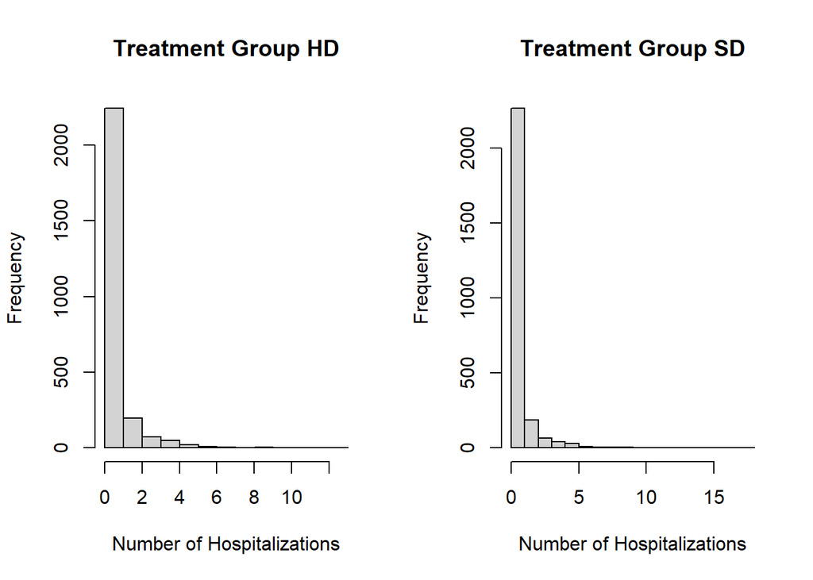

```r
par(mfrow=c(1,2))
hist(count1$status, main = "Treatment Group HD", xlab ="Number of Hospitalizations")

count2 <- aggregate(status ~ patid, data = group2, FUN = function(x) sum(x == 1))
hist(count2$status, main = "Treatment Group SD", xlab ="Number of Hospitalizations")
```

```r
# Max number of hospitalizations in HD group:
max(table1)
```

[output not shown]

```r
# Max number of hospitalizations in SD group:
max(table2)
```

[output not shown]

## 2.1

With death as a competing risk, estimate, plot and test the cumulative incidence function for the first hospitalization between the two treatment groups.

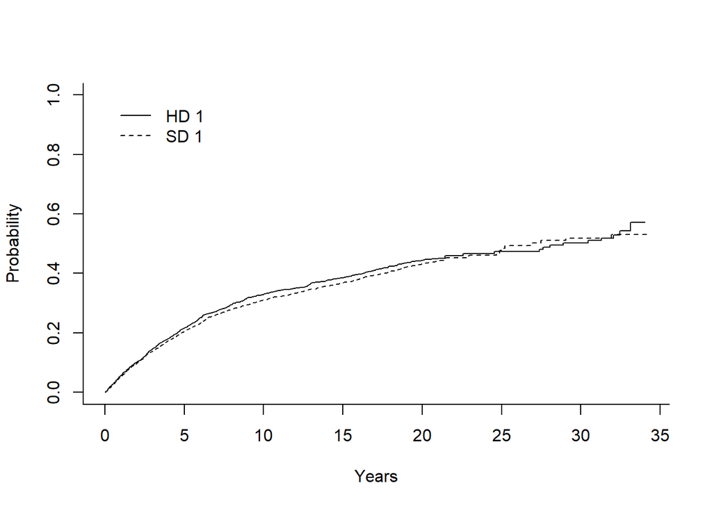

```r
library(cmprsk)

# data for first hospitalization
index <- order(invested$patid,data$time)
invested <- invested[index,]
invested2$status <- (invested2$status>0)+0

# Estimate cumulative incidence
obj <- cuminc(invested2$time, invested2$status, invested2$trtmnt, rho=0)

# Plot cumulative incidence
plot(obj)
```

## 2.2.1

Fit a multiplicative intensity frailty model for recurrent hospitalizations against the treatment and other risk factors (assuming death is independent of hospitalizations conditioning on the frailty, so it can be treated as censoring);

[output not shown]

```r
# Fit a Cox proportional hazards model with shared frailty for recurrent hospitalizations
frailty_model <- coxph(formula = Surv(start, time, status) ~ factor(trtmnt) +
                         gender + age + factor(race) + dbmi + factor(lveflt40) + factor(priormi) +
                         factor(priorhf) + factor(diab) + factor(renal) + factor(ischstr) +
                         factor(pad) + frailty(patid, dist = "gamma"),
                       data = invested)
# Print the summary of the model
summary(frailty_model)
```

```
## Call:
## coxph(formula = Surv(start, time, status) ~ factor(trtmnt) +
##     gender + age + factor(race) + dbmi + factor(lveflt40) + factor(priormi) +
##     factor(priorhf) + factor(diab) + factor(renal) + factor(ischstr) +
##     factor(pad) + frailty(patid, dist = "gamma"), data = invested)
##
##   n= 8343, number of events= 3629
##    (62 observations deleted due to missingness)
##
##                           coef      se(coef) se2      Chisq   DF   p
## factor(trtmnt)SD          -0.040999 0.053361 0.036228    0.59    1  4.4e-01
## genderMale                -0.007326 0.060820 0.041720    0.01    1  9.0e-01
## genderOther                0.652032 0.848311 0.367166    0.59    1  4.4e-01
## age                        0.005876 0.002297 0.001597    6.55    1  1.1e-02
## factor(race)Asian/Pacific -0.499580 0.321945 0.237773    2.41    1  1.2e-01
## factor(race)Black/African  0.524710 0.270443 0.192215    3.76    1  5.2e-02
## factor(race)Other          0.098932 0.311935 0.220721    0.10    1  7.5e-01
## factor(race)White          0.145622 0.265082 0.189580    0.30    1  5.8e-01
## dbmi                       0.011837 0.003646 0.002455   10.54    1  1.2e-03
## factor(lveflt40)Yes        0.476001 0.056403 0.038352   71.22    1  3.2e-17
## factor(priormi)Yes         0.150399 0.075216 0.049920    4.00    1  4.6e-02
## factor(priorhf)Yes         0.546406 0.065634 0.041302   69.31    1  8.4e-17
## factor(diab)Yes            0.225569 0.056504 0.037882   15.94    1  6.5e-05
## factor(renal)Yes           0.748850 0.057001 0.037906  172.59    1  2.0e-39
## factor(ischstr)Yes         0.324402 0.092842 0.059101   12.21    1  4.8e-04
## factor(pad)Yes             0.186033 0.121788 0.076114    2.33    1  1.3e-01
## frailty(patid, dist = "ga                             4980.48 2593 1.3e-153
##
##                           exp(coef) exp(-coef) lower .95 upper .95
## factor(trtmnt)SD             0.9598     1.0419    0.8645     1.066
## genderMale                   0.9927     1.0074    0.8811     1.118
## genderOther                  1.9194     0.5210    0.3640    10.122
## age                          1.0059     0.9941    1.0014     1.010
## factor(race)Asian/Pacific    0.6068     1.6480    0.3228     1.140
## factor(race)Black/African    1.6900     0.5917    0.9947     2.871
## factor(race)Other            1.1040     0.9058    0.5990     2.035
## factor(race)White            1.1568     0.8645    0.6880     1.945
## dbmi                         1.0119     0.9882    1.0047     1.019
## factor(lveflt40)Yes          1.6096     0.6213    1.4412     1.798
## factor(priormi)Yes           1.1623     0.8604    1.0030     1.347
## factor(priorhf)Yes           1.7270     0.5790    1.5186     1.964
## factor(diab)Yes              1.2530     0.7981    1.1217     1.400
## factor(renal)Yes             2.1146     0.4729    1.8910     2.365
## factor(ischstr)Yes           1.3832     0.7230    1.1531     1.659
## factor(pad)Yes               1.2045     0.8302    0.9487     1.529
##
## Iterations: 7 outer, 41 Newton-Raphson
##      Variance of random effect= 1.722669   I-likelihood = -28175.3
## Degrees of freedom for terms=    0.5    0.7    0.5    2.0    0.5    0.5    0.4    0.4    0.4    0.4    0.4    0.4 2592.6
## Concordance= 0.888  (se = 0.002 )
## Likelihood ratio test= 7316  on 2600 df,   p=<2e-16
```

## 2.2.2

Fit a Cox model for overall survival with the same set of covariates.

```r
# Fit a Cox proportional hazards model for overall survival
survival_model <- coxph(Surv(time, status != 0) ~ trtmnt + gender + age + race + dbmi +
                          lveflt40 + priormi + priorhf + diab + renal + ischstr + pad,
                        data = invested)

# Print the summary of the model
summary(survival_model)
```

```
## Call:
## coxph(formula = Surv(time, status != 0) ~ trtmnt + gender + age +
##     race + dbmi + lveflt40 + priormi + priorhf + diab + renal +
##     ischstr + pad, data = invested)
##
##   n= 8405, number of events= 3631
##
##                                 coef exp(coef)  se(coef)      z Pr(>|z|)
## trtmntSD                   -0.032976  0.967561  0.033286 -0.991  0.32183
## genderMale                 -0.012467  0.987610  0.038293 -0.326  0.74475
## genderOther                 0.148505  1.160099  0.356353  0.417  0.67687
## age                         0.002799  1.002803  0.001516  1.846  0.06488 .
## raceAsian/Pacific Islander -0.387080  0.679037  0.228079 -1.697  0.08967 .
## raceBlack/African American  0.335784  1.399036  0.184086  1.824  0.06814 .
## raceOther                   0.052115  1.053497  0.210365  0.248  0.80434
## raceWhite                   0.069208  1.071660  0.181628  0.381  0.70317
## dbmi                        0.006671  1.006693  0.002272  2.936  0.00332 **
## lveflt40Yes                 0.286663  1.331975  0.035147  8.156 3.46e-16 ***
## priormiYes                  0.029684  1.030129  0.044838  0.662  0.50795
## priorhfYes                  0.326237  1.385744  0.037884  8.611  < 2e-16 ***
## diabYes                     0.173425  1.189371  0.034857  4.975 6.52e-07 ***
## renalYes                    0.479004  1.614466  0.035712 13.413  < 2e-16 ***
## ischstrYes                  0.163900  1.178096  0.053361  3.072  0.00213 **
## padYes                      0.103752  1.109325  0.068887  1.506  0.13204
## ---
## Signif. codes:  0 '***' 0.001 '**' 0.01 '*' 0.05 '.' 0.1 ' ' 1
##
##                            exp(coef) exp(-coef) lower .95 upper .95
## trtmntSD                      0.9676     1.0335    0.9065     1.033
## genderMale                    0.9876     1.0125    0.9162     1.065
## genderOther                   1.1601     0.8620    0.5770     2.333
## age                           1.0028     0.9972    0.9998     1.006
## raceAsian/Pacific Islander    0.6790     1.4727    0.4343     1.062
## raceBlack/African American    1.3990     0.7148    0.9753     2.007
## raceOther                     1.0535     0.9492    0.6975     1.591
## raceWhite                     1.0717     0.9331    0.7507     1.530
## dbmi                          1.0067     0.9934    1.0022     1.011
## lveflt40Yes                   1.3320     0.7508    1.2433     1.427
## priormiYes                    1.0301     0.9708    0.9435     1.125
## priorhfYes                    1.3857     0.7216    1.2866     1.493
## diabYes                       1.1894     0.8408    1.1108     1.273
## renalYes                      1.6145     0.6194    1.5053     1.732
## ischstrYes                    1.1781     0.8488    1.0611     1.308
## padYes                        1.1093     0.9014    0.9692     1.270
##
## Concordance= 0.619  (se = 0.005 )
## Likelihood ratio test= 648.6  on 16 df,   p=<2e-16
## Wald test            = 664.5  on 16 df,   p=<2e-16
## Score (logrank) test = 685.2  on 16 df,   p=<2e-16
```

## 2.2.3

The direction and magnitude of the covariate effects can be interpreted from the coefficient estimates and corresponding p-values in the summary output of the models. Positive coefficients indicate higher risk, while negative coefficients indicate lower risk. A p-value less than 0.05 indicates statistical significance.

## 2.3

```r
library(rmt)
data <- read.table('invested2.txt')
id <- data$patid
time <- data$time
status <- data$status
trt <- data$trtmnt

fit <- rmtfit(id, time, status, trt, type="recurrent")

summary(fit,Kmax=1,tau=3.97)
```

```
## Call:
## rmtfit.default(id = id, time = time, status = status, trt = trt,
##     type = "recurrent")
##
## Restricted mean winning time by tau = 3.97:
##      Event 1    Event 2     Event 3     Event 4      Event 5 Event 6 Event 7
## HD 0.2541689 0.03489303 0.008235386 0.001823197 1.647305e-03       0       0
## SD 0.2567621 0.04674319 0.006866617 0.002420455 6.238074e-05       0       0
##    Event 8 Event 9 Event 10 Event 11 Event 12 Event 13 Event 14 Event 15
## HD       0       0        0        0        0        0        0        0
## SD       0       0        0        0        0        0        0        0
##    Event 16 Event 17 Event 18   Survival   Overall
## HD        0        0        0 0.04261663 0.3433845
## SD        0        0        0 0.04794058 0.3607954
##
## Restricted mean time in favor of group "SD" by time tau = 3.97:
##           Estimate   Std.Err Z value Pr(>|z|)
## Event 1+ 0.0120869 0.0231924  0.5212   0.6023
## Survival 0.0053240 0.0094063  0.5660   0.5714
## Overall  0.0174109 0.0269684  0.6456   0.5185
```

[figure not shown]

## 3.1

Using the treatment variable and key risk factors, build a survival tree for the composite endpoint of hospitalization-free survival (i.e., time to the first composite event).

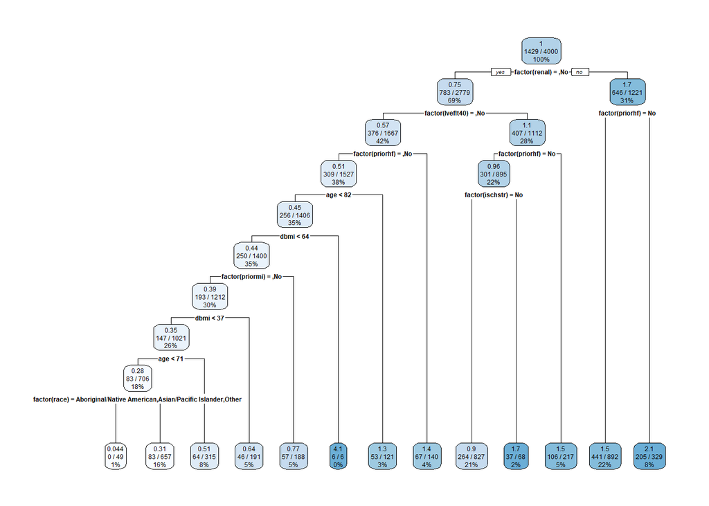

```r
library(rpart)
library(rpart.plot)
o <- order(data$patid,data$time)
dat <- data[o,]
data.CE <- dat[!duplicated(dat$patid),]
data.CE <- data.CE[data.CE$time>0,]
data.CE$status <- (data.CE$status>0)+0
set.seed(1234)
n <- nrow(data.CE)
ind <- sample(1:n)[1:4000]
train <- data.CE[ind,]
test <- data.CE[-ind,]

set.seed(12345)
obj <- rpart(Surv(time, status) ~ factor(trtmnt) + factor(gender) + age + factor(race) +
               dbmi + factor(lveflt40) + factor(priormi) + factor(priorhf) +
               factor(diab) + factor(renal) + factor(ischstr) + factor(pad),
             control = rpart.control(xval = 10, minbucket = 2, cp=0),
             data = train )

cptable <- obj$cptable
# complexity parameter values
CP <- cptable[,1]
# obtain the optimal parameter
cp.opt <- CP[which.min(cptable[,4])]
# Prune the tree
fit <- prune(obj, cp = cp.opt)

rpart.plot(fit)
```

## 3.2

Based on the survival tree built in 3.1, plot the predicted hospitalization-free survival curves for two new patients, one treated with SD and the other HD, both: female; 60 years old; white; BMI 25; LVEF < 40%; with prior histories of MI, HF, diabetes, renal impairment, ischemic stroke, and peripheral artery disease.

```r
# create data frames for the new patients
pat1 <- data[1,]
pat1$trtmnt <- 'SD'
pat1$gender <- 'Female'
pat1$age <- 60
pat1$race <- 'White'
pat1$dbmi <- 25
pat1$lveflt40 <- 'Yes'
pat1$priormi <- 'Yes'
pat1$priorhf <- 'Yes'
pat1$diab <- 'Yes'
pat1$renal <- 'Yes'
pat1$ischstr <- 'Yes'
pat1$pad <- 'Yes'
pat2 <- pat1
pat2$trtmnt <- 'HD'
# Get the KM estimates for the outcome in each terminal node
km <- survfit(Surv(time, status) ~ fit$where, train)
tmp <- summary(km)
tmp.strata <- as.integer(sub(".*=", "", tmp$strata))
tmp.t <- tmp$time
tmp.surv <- tmp$surv


# Number of terminal nodes
TN <- unique(tmp.strata)
N <- length(TN)

# Combine the predicted survival rates together, as functions of t
t <- sort(unique(tmp.t))
m <- length(t)
fitted_surv=matrix(NA,m,N)
for (j in 1:m){
tj <- t[j]
for (k in 1:N){
tk <- c(0,tmp.t[tmp.strata==TN[k]])
survk <- c(1,tmp.surv[tmp.strata==TN[k]])
fitted_surv[j,k] <- survk[sum(tk<=tj)]
}
}

# Get the terminal node prediction
# for the test data
library(treeClust)
test_term1 <- rpart.predict.leaves(fit, pat1)
n <- length(test_term1)
St_tree1 <- matrix(NA,n,m)
for (k in 1:N){
ind <- which(test_term1==TN[k])
St_tree1[ind,] <- matrix(fitted_surv[,k], nrow=length(ind),
ncol=m, byrow=TRUE)
}
```

[output not shown]

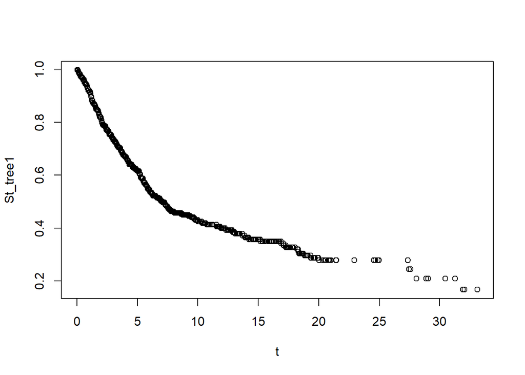

```r
plot(t, St_tree1)
```

```r
test_term2 <- rpart.predict.leaves(fit, pat2)
n <- length(test_term2)
St_tree2 <- matrix(NA,n,m)

for (k in 1:N){
ind <- which(test_term1==TN[k])
St_tree2[ind,] <- matrix(fitted_surv[,k], nrow=length(ind),
ncol=m, byrow=TRUE)
}
```

[output not shown]

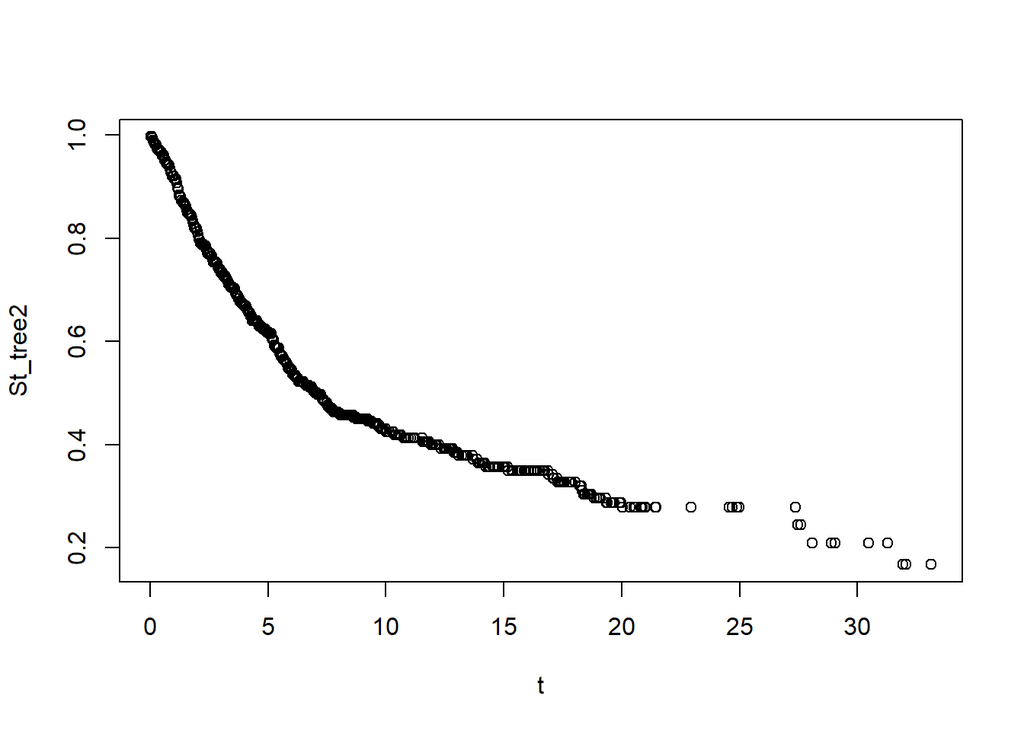

```r
plot(t, St_tree2)
```